# MAST90045 Assignment 2

Due on 3 May 2022

10 pts go to presentation for effective demonstration of your understanding, including code, LaTeX, and overall writing.

# Question 1 (56 pts)

Imagine you are an entomologist studying new species on two remote islands (island A and island B) to develop new taxonomy of related species. You hire local people to catch insects and take measurements of their body lengths. Each measurement is assumed to be independently collected.

You have received 100 measurements of a new species from the island A. A histogram looks as follows.

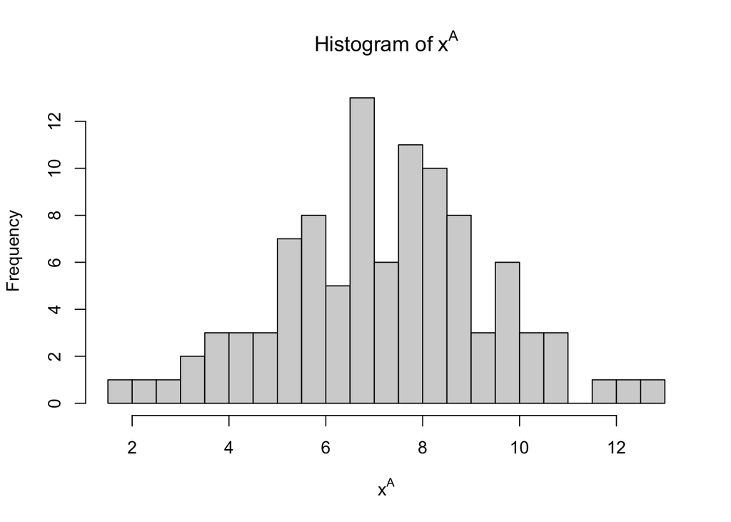

Given the histogram, you have decided to use a normal distribution $X^A\sim N(\mu_1,\sigma_1^2)$ as a probabilistic model to describe the body length distribution.

In settings like this, the standard approach to specifying the model (i.e., specifying $\mu_1$ and $\sigma_1$ in this case) is **maximum likelihood estimation** (MLE). The idea of MLE is that, given the parameterised probabilistic model, we search for a parameter that most likely gives rise to the observed data. Formally, the best parameter $(\theta^*)$ is a solution to the following optimisation problem:
$$\theta^* \in \underset{\theta\in\Theta}{\operatorname{argmax}} \prod_{n=1}^N f(x_n;\theta),$$
where

- $f$ is the PMF/PDF for $N$ independent random variables $\{X_n\}_{n=1}^N$ parameterised by $\theta$, and
- $\{x_n\}_{n=1}^N$ is the corresponding observed data.

The objective function is a function of $\theta$, the product of $N$ function values obtained by evaluating the PMF/PDF at $\{x_n\}_{n=1}^N$ for $\theta$. The multiplication is justified by the independence of $\{X_n\}_{n=1}^N$. Note that
$$\underset{\theta\in\Theta}{\operatorname{argmax}} \log\left(\prod_{n=1}^N f(x_n;\theta)\right) = \underset{\theta\in\Theta}{\operatorname{argmax}} \prod_{n=1}^N f(x_n;\theta),$$
and the left-hand side is typically easier to work with in both analytical and numerical optimisation.

In this question, if using numerical optimisers, you are asked to practise using R built-in optimiser `optim` with `method="L-BFGS-B"`, a popular choice among applied researchers.

## 1-1 (3 pts)

Back to the island A. The data is denoted by $\{x_n^A\}_{n=1}^{100}$. Let $\theta^A = (\mu_1, \sigma_1) \in \Theta^A$ where $\Theta^A=\mathbb{R}\times\mathbb{R}_{++}$ (i.e., $\sigma_1 > 0$). Now, based on the modelling assumption $X^A\sim N(\mu_1,\sigma_1^2)$, formulate a maximisation problem.

### Solution

$$\begin{align}
&\;\max_{\theta^A\in\Theta^A} \prod_{n=1}^{100} f(x_n^A;\theta^A)\\
= &\;\max_{\theta^A\in\Theta^A} \prod_{n=1}^{100}
\frac{1}{\sqrt{2\pi\sigma_1^2}}\exp\left(-\frac{1}{2\sigma_1^2}(x_n^A-\mu_1)^2\right)
\end{align}$$

## 1-2 (5 pts)

Find a local maximiser $\hat{\theta}^{A}$ and round it to one decimal place. If using `optim`, make an explicit choice of `lower` and `upper` to restrict the search region, which will be helpful. In addition, as usual, an initial value `par` matters. Of course, the above histogram helps you make educated guesses.

### Solution

```r
# Likelihood for the model A
L.A <- function(theta) {
  m1 <- theta[1]
  s1 <- theta[2]
  # -100/2log(2pi) is dropped as irrelevant
  L <- sum(-log(s1) - (X.A-m1)^2/(2*s1^2))
  return(-L)
}

re <- optim(par=c(7,2), fn=L.A, method="L-BFGS-B", lower=c(5,0.1), upper=c(10,5))
theta_hat.A <- round(re$par,1)
theta_hat.A
```

```
## [1] 7.3 2.1
```

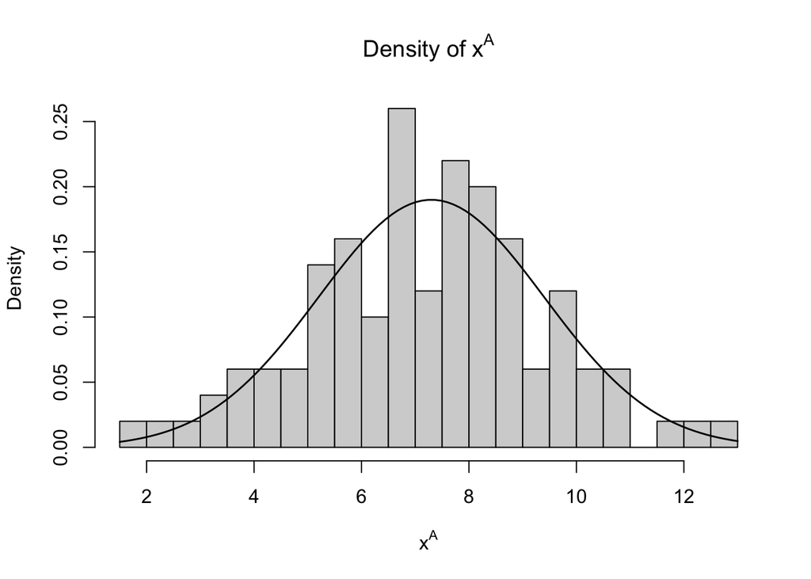

## 1-3 (3 pts)

Moving on to the island B. You have received 300 measurements of new species from the island B. A histogram looks as follows.

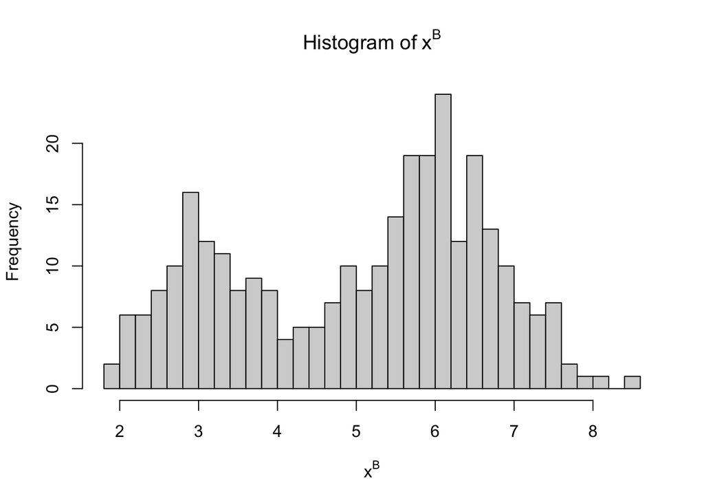

While you are certain that there are **two** new species (species 2 and 3) whose size distributions are distinct, local people were unable to tell the difference and recorded only measurements of lengths. Encouraged by the above histogram, your conviction that the data came from two distinct species leads to the following model.

The new species’ body length distribution consists of two normal distributions—it is drawn from $N(\mu_2, \sigma_2^2)$ with probability $q$ and drawn from $N(\mu_3, \sigma_3^2)$ with probability $1-q$ where $q\in(0,1)$. In other words, the PDF for this random variable $X^B$ is
$$f(x^B) = \frac{q}{\sqrt{2\pi\sigma_2^2}}\exp\left(-\frac{1}{2\sigma_2^2}(x^B-\mu_2)^2\right) +
\frac{1-q}{\sqrt{2\pi\sigma_3^2}}\exp\left(-\frac{1}{2\sigma_3^2}(x^B-\mu_3)^2\right).$$

Show that $f(x^B)$ is indeed a legitimate PDF by showing that it is non-negative and integrates to $1$.

## Solution

Since $q\in(0,1)$ and $\exp(\cdot)>0$, $f(x^B)$ is indeed strictly positive for all $x^B\in\mathbb{R}$. Now, observe:

$$\begin{align}
&\;\int_{-\infty}^\infty f(x^B)dx^B\\
= &\;\int_{-\infty}^\infty \frac{q}{\sqrt{2\pi\sigma_2^2}}\exp\left(-\frac{1}{2\sigma_2^2}(x^B-\mu_2)^2\right) + \frac{1-q}{\sqrt{2\pi\sigma_3^2}}\exp\left(-\frac{1}{2\sigma_3^2}(x^B-\mu_3)^2\right)dx^B\\
= &\;q\int_{-\infty}^\infty \frac{1}{\sqrt{2\pi\sigma_2^2}}\exp\left(-\frac{1}{2\sigma_2^2}(x^B-\mu_2)^2\right)dx^B + (1-q)\int_{-\infty}^\infty \frac{1}{\sqrt{2\pi\sigma_3^2}}\exp\left(-\frac{1}{2\sigma_3^2}(x^B-\mu_3)^2\right)dx^B\\
= &\;q + (1-q)\\
= &\;1
\end{align}$$
where each integrand is the PDF for a normal distribution, which integrates to $1$.

## 1-4 (3 pts)

As for the island A model, using the above PDF, your approach to finding the best parameter $\theta^{B*}$ is MLE. Note that $\theta^{B}=(\mu_2,\sigma_2,\mu_3,\sigma_3,q) \in \Theta^B$ where $\Theta^B=\mathbb{R}\times\mathbb{R}_{++}\times\mathbb{R}\times\mathbb{R}_{++}\times(0,1)$. Formulate a maximisation problem.

### Solution

$$\begin{align}
&\;\max_{\theta^B\in\Theta^B} \prod_{n=1}^{300} f(x_n^B;\theta^B)\\
= &\;\max_{\theta^B\in\Theta^B} \prod_{n=1}^{300}
\frac{q}{\sqrt{2\pi\sigma_2^2}}\exp\left(-\frac{1}{2\sigma_2^2}(x_n^B-\mu_2)^2\right) +
\frac{1-q}{\sqrt{2\pi\sigma_3^2}}\exp\left(-\frac{1}{2\sigma_3^2}(x_n^B-\mu_3)^2\right)
\end{align}$$

## 1-5 (7 pts)

Try to find a local maximiser in the above problem using `optim`. Depending on your specification and creativity, you may or may not be able to solve it. If you make it, show your work and report $\hat{\theta}^B$ rounded to one decimal place. If you cannot, still show your work but make a sensible conjecture about the cause of the failure. (A satisfactory answer can get a full mark in either case.)

### Solution

As usual, first, take the $\log$ of the objective function.
$$\begin{align}
&\;\log\left(\prod_{n=1}^{300}
\frac{q}{\sqrt{2\pi\sigma_2^2}}\exp\left(-\frac{1}{2\sigma_2^2}(x_n^B-\mu_2)^2\right) +
\frac{1-q}{\sqrt{2\pi\sigma_3^2}}\exp\left(-\frac{1}{2\sigma_3^2}(x_n^B-\mu_3)^2\right)\right)\\
= &\;\sum_{n=1}^{300}\log\left(
\frac{q}{\sqrt{2\pi\sigma_2^2}}\exp\left(-\frac{1}{2\sigma_2^2}(x_n^B-\mu_2)^2\right) +
\frac{1-q}{\sqrt{2\pi\sigma_3^2}}\exp\left(-\frac{1}{2\sigma_3^2}(x_n^B-\mu_3)^2\right)\right)
\end{align}$$

This is, to me, very difficult. In the MLE for the island A model, $\log$ directly acts upon $\exp$ and makes it a quadratic function in terms of $\mu^A$, which is easy to maximise. Once we find an optimal $\mu^{A*}$, we substitute it back in the objective and solve for $\sigma^A$. The structural ease can also be exploited by numerical optimisation algorithms (e.g., [coordinate descent](https://en.wikipedia.org/wiki/Coordinate_descent)). In contrast, in the island B problem, the addition inside $\log$ prevents this from happening, leaving the objective as nasty as it is.

## 1-6 (4 pts)

You have got an idea about an alternative approach to the problem. Although $q$ itself is a deterministic parameter, it is for the probability that a body length is drawn from species 2 (and $1-q$ for species 3). So, let’s treat the species selection as another random event and define a new random variable $S$ such that
$$p(2) = q \quad\text{and}\quad p(3) = 1-q,$$
where $p(s)$ is the PMF for $S$. Then, the size distribution can be conditioned on $S=s$ as follows:
$$f(x^B|s) = \frac{1}{\sqrt{2\pi\sigma_s^2}}\exp\left(-\frac{1}{2\sigma_s^2}(x^B-\mu_s)^2\right).$$
Find an expression for $f(x^B,s)$, the joint PDF for a mix of continuous $X^B$ and discrete $S$.

### Solution

For $s\in\{2,3\}$,
$$\begin{align}
f(x^B,s) &= f(x^B|s)p(s)\\
&= \frac{1}{\sqrt{2\pi\sigma_s^2}}\exp\left(-\frac{1}{2\sigma_s^2}(x^B-\mu_s)^2\right)q^{3-s}(1-q)^{s-2}.
\end{align}$$
Otherwise,
$$f(x^B,s)=0.$$

## 1-7 (4 pts)

Marginalise $f(x^B,s)$ over $S$ to recover the marginal PDF $f(x^B)$ and marginalise $f(x^B,s)$ over $X^B$ to recover the marginal PMF $p(s)$.

### Solution

$$\begin{align}
&\;\sum_{s\in\{2,3\}} f(x^B,s)\\
= &\;\sum_{s\in\{2,3\}} \frac{1}{\sqrt{2\pi\sigma_s^2}}\exp\left(-\frac{1}{2\sigma_s^2}(x^B-\mu_s)^2\right)q^{3-s}(1-q)^{s-2}\\
= &\;\frac{1}{\sqrt{2\pi\sigma_2^2}}\exp\left(-\frac{1}{2\sigma_2^2}(x^B-\mu_2)^2\right)q + \frac{1}{\sqrt{2\pi\sigma_3^2}}\exp\left(-\frac{1}{2\sigma_3^2}(x^B-\mu_3)^2\right)(1-q)\\
= &\;f(x^B)\\
\\
&\;\int_{-\infty}^\infty f(x^B,s)dx^B\\
= &\;\int_{-\infty}^\infty \frac{1}{\sqrt{2\pi\sigma_s^2}}\exp\left(-\frac{1}{2\sigma_s^2}(x^B-\mu_s)^2\right)q^{3-s}(1-q)^{s-2}dx^B\\
= &\;q^{3-s}(1-q)^{s-2}\int_{-\infty}^\infty \frac{1}{\sqrt{2\pi\sigma_s^2}}\exp\left(-\frac{1}{2\sigma_s^2}(x^B-\mu_s)^2\right)dx^B\\
= &\;q^{3-s}(1-q)^{s-2}\\
= &\;p(s)
\end{align}$$

## 1-8 (7 pts)

At this point, you come to terribly regret not telling the local people how to distinguish two species so that they can also record the species for each measurement. Why? Explain in detail how the knowledge of species for each measurement could make your MLE easier.

Note that, the independence implies that the joint PDF for all 300 pairs of random variables $\{(X_n^B,S_n)\}_{n=1}^{300}$ is simply the product of each component PDF $f(x_n^B,s_n; \theta^B)$:
$$\prod_{n=1}^{300} f(x_n^B,s_n; \theta^B).$$

## Solution

If we had data $\{s_n\}_{n=1}^{300}$ in addition to $\{x_n^B\}_{n=1}^{300}$, we could solve the following maximisation problem for MLE of $\theta^B$:
$$\max_{\theta^B\in\Theta^B} \log\left(\prod_{n=1}^{300} f(x_n^B,s_n; \theta^B)\right).$$
Note that $f(x_n^B,s_n; \theta^B)$ for each $n\in\{1,2\dots,300\}$ is simply either
$$p(2)f(x_n^B|2; \mu_2,\sigma_2) = \frac{q}{\sqrt{2\pi\sigma_2^2}}\exp\left(-\frac{1}{2\sigma_2^2}(x_n^B-\mu_2)^2\right)$$
or
$$p(3)f(x_n^B|3; \mu_3,\sigma_3) = \frac{1-q}{\sqrt{2\pi\sigma_3^2}}\exp\left(-\frac{1}{2\sigma_3^2}(x_n^B-\mu_3)^2\right).$$
Thus, the maximisation problem can be rewritten as follows:
$$\begin{align}
&\; \max_{\theta^B\in\Theta^B} \log\left(\prod_{n=1}^{300} f(x_n^B,s_n; \theta^B)\right)\\
=&\; \max_{\theta^B\in\Theta^B} \sum_{n=1}^{300} \log\left(f(x_n^B,s_n; \theta^B)\right)\\
=&\; \max_{\theta^B\in\Theta^B} \left[ \sum_{n : s_n=2} \log\left(f(x_n^B,2; \mu_2,\sigma_2,q)\right) + \sum_{n : s_n=3} \log\left(f(x_n^B,3; \mu_3,\sigma_3,q)\right) \right]\\
=&\; \max_{\theta^B\in\Theta^B} \left[ \sum_{n : s_n=2} \log\left(q\cdot f(x_n^B|2; \mu_2,\sigma_2)\right) + \sum_{n : s_n=3} \log\left((1-q)\cdot f(x_n^B|3; \mu_3,\sigma_3)\right) \right]\\
=&\; \max_{\theta^B\in\Theta^B} \left[ \sum_{n : s_n=2} \log(q)+\log\left(f(x_n^B|2; \mu_2,\sigma_2)\right) + \sum_{n : s_n=3} \log(1-q)+\log\left(f(x_n^B|3; \mu_3,\sigma_3)\right) \right]\\
=&\; \max_{q} \left[ \sum_{n : s_n=2}\log(q)+\sum_{n : s_n=3}\log(1-q) \right] +\\
&\quad\quad \max_{\mu_2,\sigma_2}\sum_{n : s_n=2} \log\left(f(x_n^B|2; \mu_2,\sigma_2)\right) + \max_{\mu_3,\sigma_3}\sum_{n : s_n=3} \log\left(f(x_n^B|3; \mu_3,\sigma_3)\right).
\end{align}$$
The first maximisation is easy, $q^*$ is the proportion of species 2. Therefore, despite three more parameters to optimise, this problem is almost as tractable as the one for the island A model.

By the way, the hidden $\{s_n\}_{n=1}^{300}$ is stored in `S` in this solution. So, let’s run the MLE.

```r
q.star <- length(S[S==2])/length(S)

L.B2 <- function(theta) {
  m2 <- theta[1]
  s2 <- theta[2]
  # The constant is dropped as irrelevant
  L <- sum(-log(s2) - (X.B[S==2]-m2)^2/(2*s2^2))
  return(-L)
}
re <- optim(par=c(3,1), fn=L.B2, method="L-BFGS-B", lower=0.1, upper=c(6,3))
m2.star <- re$par[1]
s2.star <- re$par[2]

L.B3 <- function(theta) {
  m3 <- theta[1]
  s3 <- theta[2]
  # The constant is dropped as irrelevant
  L <- sum(-log(s3) - (X.B[S==3]-m3)^2/(2*s3^2))
  return(-L)
}
re <- optim(par=c(6,5), fn=L.B3, method="L-BFGS-B", lower=0.1, upper=c(8,5))
m3.star <- re$par[1]
s3.star <- re$par[2]

round(c(m2.star,s2.star,m3.star,s3.star,q.star), 1)
```

```
## [1] 3.0 0.5 6.0 1.0 0.3
```

These MLE estimates happen to be exactly the true underlying parameters!

## 1-9 (5 pts)

You are tenacious and start thinking along the following lines. Now, the species selection $S$ is a random variable, and the knowledge of species for each measurement could make the MLE easier. Although $S$ is unmeasured, we know its distribution as a function of $\theta^B$. So, to eliminate the dependency on $\{s_n\}_{n=1}^{300}$, let’s take the expectation of the MLE objective with respect to $\{S_n\}_{n=1}^{300}$ and then maximise it. In particular, to make use of the measurement data $\{x_n^B\}_{n=1}^{300}$, let’s use the expectation with respect to the posterior PMF of $\{S_n\}_{n=1}^{300}$,
$$p(\mathbf{s}|\mathbf{x}^B; \theta^B),$$
where $\mathbf{s}=(s_{1}, s_{2},\dots, s_{300})$ and $\mathbf{x}^B=(x_{1}^B, x_{2}^B,\dots, x_{300}^B)$.

Find an expression for $p(\mathbf{s}|\mathbf{x}^B; \theta^B)$.

### Solution

$$\begin{align}
p(\mathbf{s}|\mathbf{x}^B; \theta^B)
&= \frac{p(\mathbf{s},\mathbf{x}^B;\theta^B)}{p(\mathbf{x}^B;\theta^B)}\\
&= \frac{\prod_{n=1}^{300} f(x_n^B,s_n; \theta^B)}{\prod_{n=1}^{300}f(x_n^B;\theta^B)}\\
&= \prod_{n=1}^{300} \frac{f(x_n^B,s_n; \theta^B)}{f(x_n^B;\theta^B)}\\
&= \prod_{n=1}^{300} \frac{\frac{1}{\sqrt{2\pi\sigma_s^2}}\exp\left(-\frac{1}{2\sigma_s^2}(x_n^B-\mu_s)^2\right)q^{3-s}(1-q)^{s-2}}{\frac{q}{\sqrt{2\pi\sigma_2^2}}\exp\left(-\frac{1}{2\sigma_2^2}(x_n^B-\mu_2)^2\right) + \frac{1-q}{\sqrt{2\pi\sigma_3^2}}\exp\left(-\frac{1}{2\sigma_3^2}(x_n^B-\mu_3)^2\right)}\\
&= \prod_{n=1}^{300} p(s_n|x_n^B; \theta^B),
\end{align}$$
which implies that $\{S_n|X_n=x_n\}_{n=1}^{300}$ are independent of each other.

## 1-10 (7 pts)

Here is the formal description of the above idea. In search of $\theta^{B*}$,

0. Begin with some initial $\theta_{old}^{B}$.
1. With $\theta_{old}^{B}$, specify $p(\mathbf{s}|\mathbf{x}^B; \theta_{old}^{B})$.
2. Find a local maximiser $\theta_{new}^{B}$ by solving
   $$\underset{\theta^B\in\Theta^B}{\operatorname{argmax}} \mathbb{E}\left[\log\left(\prod_{n=1}^{300} f(x_n^B,S_n; \theta^{B})\right)\right],$$
   where the expectation is taken with respect to $p(\mathbf{s}|\mathbf{x}^B; \theta_{old}^{B})$.
3. If $\|\theta_{new}^{B}-\theta_{old}^{B}\| > \epsilon$, go back to #1 and repeat the process using $\theta_{new}^{B}$ in place of $\theta_{old}^{B}$; Otherwise, you are done.

To implement the algorithm, first, you need to make Step #2 more explicit. Using $p(\mathbf{s}|\mathbf{x}^B; \theta^B)$ found in Q1-9, find an expression for the objective $\mathbb{E}\left[\log\left(\prod f(x_n^B,S_n; \theta^{B})\right)\right]$. Your expression should be in terms of $\mu_2$, $\sigma_2$, $\mu_3$, $\sigma_3$, $q$, $\theta_{old}^B$, and $x_1^B, x_2^B, \dots, x_{300}^B$.

### Solution

Remember that the expectation is taken with respect to $\{S_n|X_n=x_n; \theta_{old}^{B}\}_{n=1}^{300}$.
$$\begin{align}
&\; \mathbb{E}\left[\log\left(\prod_{n=1}^{300} f(x_n^B,S_n; \theta^{B})\right)\right]\\
=&\; \mathbb{E}\left[\sum_{n=1}^{300} \log\left(f(x_n^B,S_n; \theta^{B})\right)\right]\\
=&\; \sum_{n=1}^{300} \mathbb{E}\left[\log\left(f(x_n^B,S_n; \theta^{B})\right)\right]\\
=&\; \sum_{n=1}^{300} \mathbb{E}_{S_{-n}}\mathbb{E}_{S_n}\left[\log\left(f(x_n^B,S_n; \theta^{B})\right)\right]\\
=&\; \sum_{n=1}^{300} \mathbb{E}_{S_n}\left[\log\left(f(x_n^B,S_n; \theta^{B})\right)\right]\\
=&\; \sum_{n=1}^{300}\sum_{s_n\in\{2,3\}} p(s_n|x_n^B; \theta_{old}^B)\log\left(f(x_n^B,s_n; \theta^{B})\right)\\
=&\; \sum_{n=1}^{300} p(2|x_n^B;\theta_{old}^B)\log\left(f(x_n^B,2; \theta^{B})\right) + p(3|x_n^B; \theta_{old}^B)\log\left(f(x_n^B,3; \theta^{B})\right)\\
=&\; \sum_{n=1}^{300} p(2|x_n^B;\theta_{old}^B)\left(\log(q) - \frac{1}{2}\log(2\pi) - \log(\sigma_2) - \frac{(x_n^B-\mu_2)^2}{2\sigma_2^2}\right) +\\
&\quad\quad p(3|x_n^B;\theta_{old}^B)\left(\log(1-q) - \frac{1}{2}\log(2\pi) - \log(\sigma_3) - \frac{(x_n^B-\mu_3)^2}{2\sigma_3^2}\right)\\
=&\; -\frac{300}{2}\log(2\pi) + \sum_{n=1}^{300} p(2|x_n^B;\theta_{old}^B)\left(\log(q) - \log(\sigma_2) - \frac{(x_n^B-\mu_2)^2}{2\sigma_2^2}\right) +\\
&\hspace{8em} p(3|x_n^B;\theta_{old}^B)\left(\log(1-q) - \log(\sigma_3) - \frac{(x_n^B-\mu_3)^2}{2\sigma_3^2}\right),
\end{align}$$
where $\mathbb{E}$ with respect to all 300 $S$s is split into $\mathbb{E}_{S_n}$ and $\mathbb{E}_{S_{-n}}$ (299 $S$s other than $n$).

## 1-11 (8 pts)

By completing the given code, find an estimate $\hat{\theta}^B$ rounded to one decimal place. As usual, to demonstrate your understanding, make sufficient comments on your code.

### Solution

```r
PMF.s <- function(x, theta) {
  m2 <- theta[1]
  s2 <- theta[2]
  m3 <- theta[3]
  s3 <- theta[4]
  q <- theta[5]

  L2 <- q/sqrt(2*pi*s2^2)*exp(-(x-m2)^2/(2*s2))
  L3 <- (1-q)/sqrt(2*pi*s3^2)*exp(-(x-m3)^2/(2*s3))

  return(c(L2/(L2+L3), L3/(L2+L3)))
}

L.B <- function(theta) {
  m2 <- theta[1]
  s2 <- theta[2]
  m3 <- theta[3]
  s3 <- theta[4]
  q <- theta[5]

  L <- 0
  # -300/2log(2pi) is dropped as irrelevant
  for (n in 1:N.B) {
    # PMF given X.B[n] (and theta.old)
    p.s <- PMF.s(X.B[n], theta.old)
    # Add the weighted average
    L <- L +
         p.s[1]*(log(q) - log(s2) - (X.B[n]-m2)^2/(2*s2^2)) +
         p.s[2]*(log(1-q) - log(s3) - (X.B[n]-m3)^2/(2*s3^2))
  }

  return(-L)
}
```

```r
tol <- 1e-3
theta.old <- c(3,1,6.5,1,.4)
theta <- theta.old + 2*tol

while(sqrt(sum((theta - theta.old)^2)) > tol) {
  re <- optim(par=theta.old, fn=L.B, method="L-BFGS-B",
              lower=0.1, upper=c(6,3,8,5,.7))
  theta.old <- theta
  theta <- re$par
}
theta_hat.B <- round(theta,1)
theta_hat.B
```

```
## [1] 3.3 0.7 6.1 0.8 0.4
```

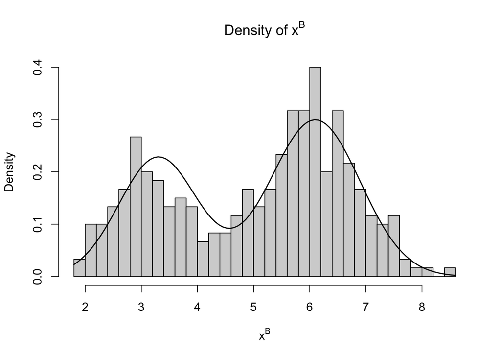

The island B model is called a **Gaussian mixture** model, and the solution algorithm is a type of the **expectation-maximisation (EM)** algorithm.

# Question 2 (34 pts)

- Q2 allows less restricted coding. Do not assume that readers are smart enough to understand your ideas with ease (one of the best advices for academic communication). Instead, make sufficient comments and effectively communicate your code.
- If using numerical root-finding, use `newtonraphson` provided in the answer source file.

In this question, you are asked to compare performance of two ODE solvers, RK4 and adaptive RK4 (ARK4), in long-term prediction using the predator-prey model from the lecture. Long-term prediction simply means large $T$, for which you compute solution $\hat{\mathbf{y}}(t)$ for $t\in [0,T]$. The performance of a solver is defined as the number of required steps for its trajectory to remain “close” to the true orbit. Recall that the orbit is defined by the implicit equation
$$c = gby_1-e\log(y_1)+by_2-a\log(y_2),$$
where $a=0.05$, $b=2\times 10^{-4}$, $g=0.8$, $e=0.03$, and $c=-0.3$. You may assume the orbit is contained in $R=[10,810]\times[20,830]$.

Closeness of a trajectory is determined by the average of all deviations computed at every visited $\hat{\mathbf{y}}(t)$. The deviation of a test location $\mathbf{y}^c \in R$ from the orbit is defined as the shortest distance to reach the orbit by moving from $\mathbf{y}^c$ to one of four directions: up, down, left, or right. For example, in the following figure, the arrows indicate the deviation from $\mathbf{y}^d=(600,730)$ and the deviation from $\mathbf{y}^e=(130,400)$.

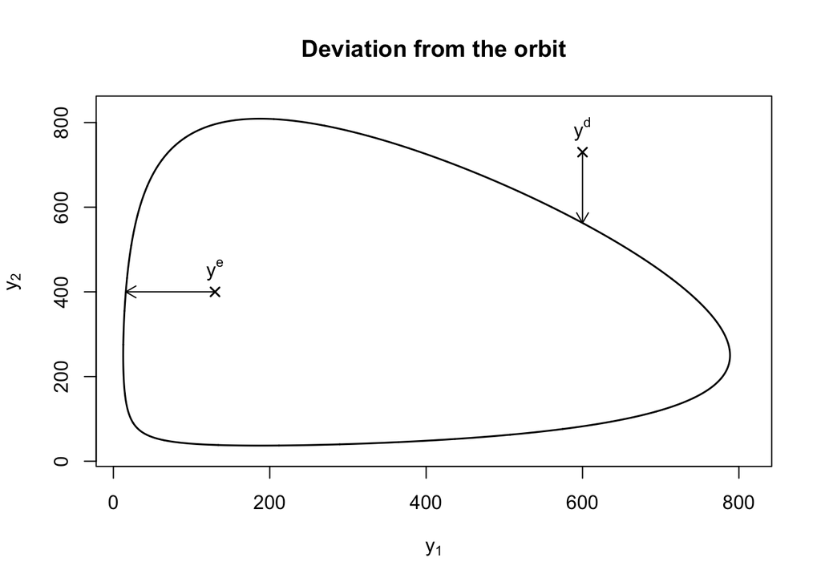

By computing the deviation of $\hat{\mathbf{y}}(t)$ for every $t\in[0,T]$, you can get the average deviation at $t=T$.

## 2-1 (10 pts)

Complete the given code that defines a function `deviation`, which takes an arbitrary `y` and returns the deviation of `y`. You can test your `deviation` using $\mathbf{y}^d$ and $\mathbf{y}^e$, which should return ~167.253 and ~114.111 respectively.

### Solution

Based on the implicit equation for the orbit
$$c = gby_1-e\log(y_1)+by_2-a\log(y_2),$$
first, define
$$f(y_1,y_2) = gby_1-e\log(y_1)+by_2-a\log(y_2)-c.$$
Then, notice that finding a distance from $\mathbf{y}^c$ to the orbit in either vertical or horizontal direction is equivalent to finding a root of $f$ with fixed $y_1=y^c_1$ or $y_2=y^c_2$ respectively. If $\mathbf{y}^c$ is in the interior of the orbit, in each direction, we should find two distances from $\mathbf{y}^c$ to the orbit, which correspond to two roots.

Remember that root finding is sensitive to initial points. So, to avoid missing a root, you should first do some heuristic search and pick a reasonably fine grid in the region $R=[10,810]\times[20,830]$ within the computational budget.

```r
deviation <- function(y) {
  N.initial <- 200 # Chosen after testing several numbers
  distances <- c()

  # Horizontal distances
  h <- function(y1) c(f(y1,y[2]), g*b-e/y1)
  for (y1 in seq(10, 810, length.out=N.initial)) {
    re <- newtonraphson(h, y1)
    if (is.null(re)==FALSE) {
      distances <- c(distances, abs(re$a - y[1]))
    }
  }

  # Vertical distances
  h <- function(y2) c(f(y[1],y2), b-a/y2)
  for (y2 in seq(20, 830, length.out=N.initial)) {
    re <- newtonraphson(h, y2)
    if (is.null(re)==FALSE) {
      distances <- c(distances, abs(re$a - y[2]))
    }
  }

  return(round(min(distances), 3))
}
```

## 2-2 (4 pts)

Compared to the implementation presented in the lecture, `RK4` here uses

- slightly different parameterisation,
- a list for a temporary solution table, and
- a separate `K4` function for slope computation.

```r
K4 <- function(f, y, h) {
  k1 <- f(y)
  k2 <- f(y + h/2*k1)
  k3 <- f(y + h/2*k2)
  k4 <- f(y + h*k3)
  return(k1/6 + k2/3 + k3/3 + k4/6)
}
```

```r
RK4 <- function(f, y0, T, N) {
  h <- T/N
  Y <- list()
  Y[[1]] <- y0

  for (n in 1:N) {
    Y[[n+1]] <- Y[[n]] + h*K4(f, Y[[n]], h)
  }

  # Convert the list to a matrix
  Y <- matrix(unlist(Y), ncol=2, byrow=T)
  return(Y)
}
```

The trajectory generated by `RK4` with $\mathbf{y}(0)=(150,803.9929)$, $T=1176$, and $N=100$ looks as follows.

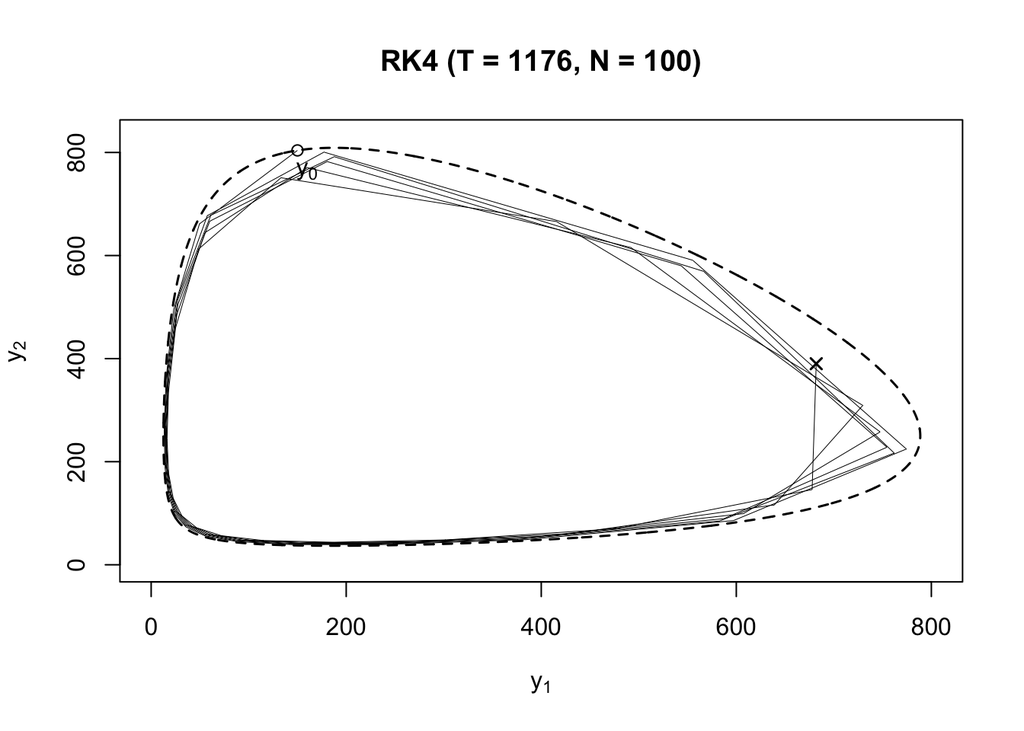

Complete the given code that computes the average deviation of the above trajectory.

### Solution

```r
Dev <- c() # store all deviations
Y.RK4 <- RK4(LV, y0, 1176, 100)
for (i in 1:dim(Y.RK4)[1]) {
  y <- Y.RK4[i,]
  Dev <- c(Dev, deviation(y))
}
print(mean(Dev)) # print the average
```

```
## [1] 9.723644
```

## 2-3 (14 pts)

Similar to [adaptive quadrature](https://ysaikai.github.io/files/numerical_integration.html#adaptive-quadrature), ARK4 keeps halving steps until the stopping criterion is met for each (sub)step.

Specifically,

0. Initialise ARK4 with $t_a=0$, $t_b=T$, and a step size $h=T$.
1. Compute $\hat{\mathbf{y}}_s(t_b)$ at $\hat{\mathbf{y}}(t_a)$ by taking a single step of size $h$ for that interval.
2. Compute $\hat{\mathbf{y}}_d(t_b)$ at $\hat{\mathbf{y}}(t_a)$ by taking double steps (i.e. two steps) of size $h/2$ for that interval.
3. Examine whether $\|\hat{\mathbf{y}}_d(t_b)-\hat{\mathbf{y}}_s(t_b)\| \leq \epsilon$.
4. If the condition is met, stop halving, take double steps of size $h/2$, and go to the next interval. Otherwise, go back to #1 for each of two subintervals $[t_a,(t_a+t_b)/2]$ and $[(t_a+t_b)/2,t_b]$ as new $[t_a,t_b]$.

Note:

- $\|\cdot\|$ is Euclidean norm,
- As for RK4 above, use `K4` function to compute slopes, and
- When halving is halted, make sure to store both steps as part of the solution.

Now, by completing the given code, implement ARK4 using a recursive function. The provided code also helps you plot the trajectory generated by ARK4 as well as the trajectory generated by RK4 with the same number of steps.

### Solution

```r
ARK4.recur <- function(f, y.a, h, y.s, Y, tol) {
  h <- h/2
  y.m <- y.a + h*K4(f, y.a, h) # after the first step
  y.d <- y.m + h*K4(f, y.m, h) # after the second step

  if (sqrt(sum((y.s - y.d)^2)) > tol) {
    Y <- ARK4.recur(f, y.a, h, y.m, Y, tol) # result for the first subinterval
    y.a <- Y[[length(Y)]] # new starting point
    y.s <- y.a + h*K4(f, y.a, h) # take a single step
    Y <- ARK4.recur(f, y.a, h, y.s, Y, tol) # result for the second subinterval
  } else {
    # Record both mid & end points when halting
    n <- length(Y)
    Y[[n+1]] <- y.m
    Y[[n+2]] <- y.d
  }

  return(Y)
}
```

```r
ARK4 <- function(f, y0, T, tol) {
  h <- T
  Y <- list()
  Y[[1]] <- y0

  y.s <- y0 + h*K4(f, y0, h)
  Y <- ARK4.recur(f, y0, h, y.s, Y, tol)

  Y <- matrix(unlist(Y), ncol=2, byrow=T)
  return(Y)
}
```

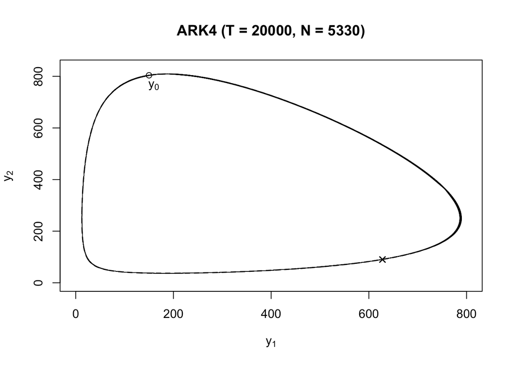

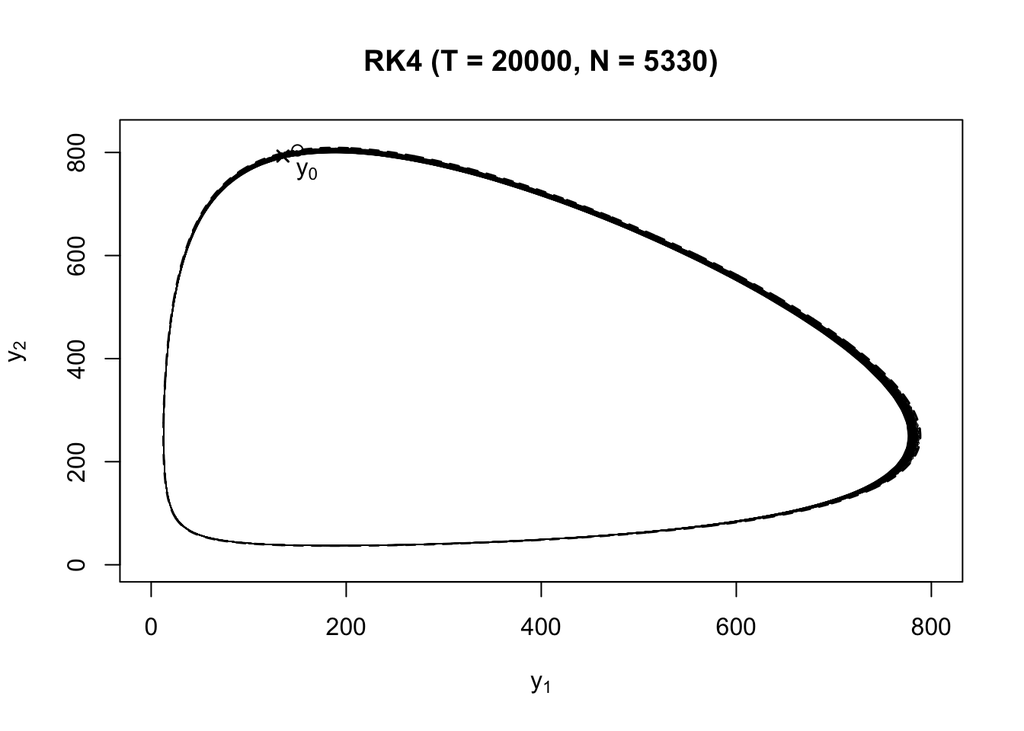

## 2-4 (6 pts)

First compute the average deviation of the ARK4 trajectory for $\mathbf{y}(0)$, $T=20000$ and $\epsilon = 0.07$. Then, find how many steps RK4 needs to take to achieve similar performance. Briefly comment on your finding.

### Solution

```r
Dev.ARK4 <- c()
for (i in 1:dim(Y.ARK4)[1]) {
  y <- Y.ARK4[i,]
  Dev.ARK4 <- c(Dev.ARK4, deviation(y))
}
print(mean(Dev.ARK4))
```

```
## [1] 0.2937987
```

```r
N <- 6860 # for example by binary search (bisection method for integers)
Y.RK4 <- RK4(LV, y0, T, N)
Dev.RK4 <- c()
for (i in 1:dim(Y.RK4)[1]) {
  y <- Y.RK4[i,]
  Dev.RK4 <- c(Dev.RK4, deviation(y))
}
print(mean(Dev.RK4))
```

```
## [1] 0.2937534
```

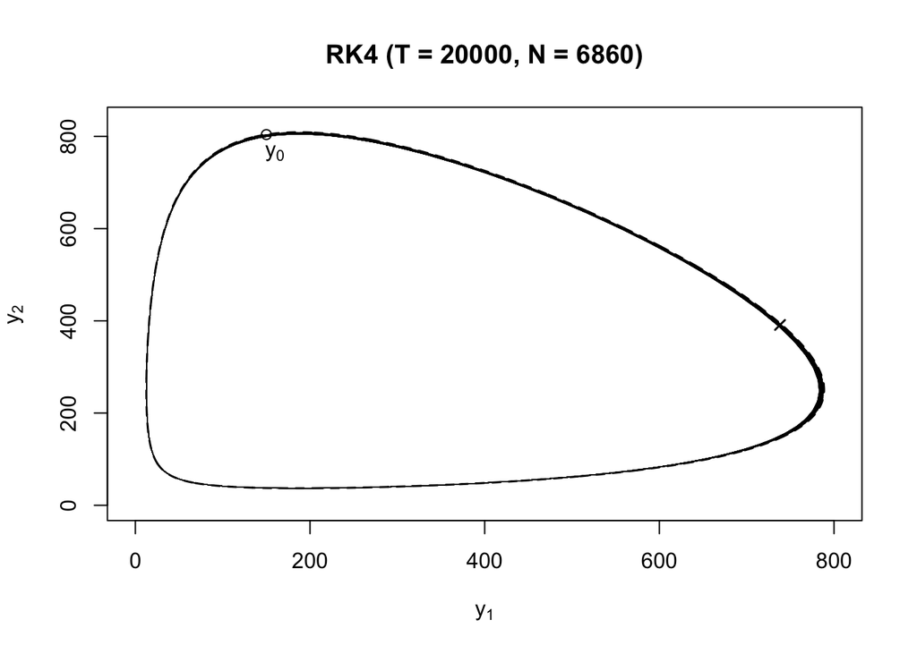

RK4 requires roughly 6860 steps, which is 1530 more steps than ARK4. ARK4 achieves this efficiency by expending more steps at regions where `LV` returns large vectors (e.g., top, top-right, and right parts of the orbit). Despite the computational overheads created when ARK4 halves a step size (i.e. discarding previously computed steps), the automatic discovery of efficient step allocation can be a useful feature of this ODE solver in some applications.